# Machine Learning Assignment

The goal of this project is to predict the manner in which test subjects did a barbell exercise based on the measurements of accelerometers. We are building a model to predict the values of the “classe” variable in the training set.

#### The process

##### Step 1.

Read the training file and remove zero-variance variables

```r
training = read.csv("pml-training.csv")
 set.seed(123)
require(caret)
```

Now identify and remove all covariates with near zero variance. Exclude the outcome from the variance analysis, then add it back to the filtered set.

```r
covs = training [,-160]

covsNZV=nearZeroVar(covs)
notZVcovs= covs[, - covsNZV]

trainingNotZV = cbind(training[,160], notZVcovs)
names(trainingNotZV)[1] <- "classe"
```

The number of covariates has been reduced from 159 to 94.

##### Step 2.

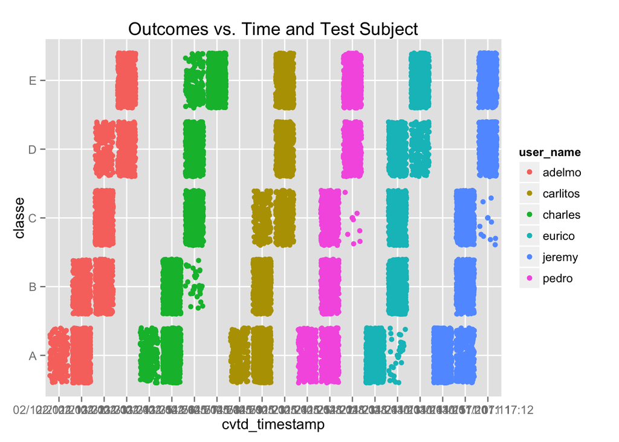

Accordingly, we can remove the variables related to the observation number, test subject, and time:

- “X” standing for observation id,
- “user_name”
- “raw_timestamp_part_1”
- “raw_timestamp_part_2”
- “cvtd_timestamp”

```r
trainingNotZV = trainingNotZV [,-2:-6]
```

##### Step3.

Prepare the training set. Now split the training sample into 2 parts for cross-validation purposes

```r
inTrain = createDataPartition(y=trainingNotZV$classe, p = 0.75, list = F)
training = trainingNotZV[inTrain,]
testing = trainingNotZV[-inTrain,]
```

We need to exclude the variables that are mostly incomplete.

```r
trainingcomp = training[,colSums(is.na(training)) == 0]
```

The number of variables has been reduced to 53.

Create preprocessing object to standardize observations, as a lot of values are around zero, and create a new traning set with standardized values:

```r
preObj = preProcess (trainingcomp [,-1])
trainingcompS <- predict(preObj, trainingcomp [,-1])
trainingcompS$classe = trainingcomp$classe
```

Generate principal components to further reduce the number of variables. I’ve tried several combinations (13 variables capture 80% of the variance) but my subsequent random forest function is running too slow if I have many components. So I’ll take 6.

```r
pca <- preProcess(trainingcompS[,-53], method = "pca", pcaComp = 6)
princomps = predict(pca, trainingcompS[,-53])
princomps$classe = trainingcompS$classe
```

##### Step 4.

Apply random forest to the training set.

```r
rf = train (classe ~ ., data=princomps, method = "rf")
rf
```

Random Forest

14718 samples 6 predictor 5 classes: ‘A’, ‘B’, ‘C’, ‘D’, ‘E’

No pre-processing Resampling: Bootstrapped (25 reps)

Summary of sample sizes: 14718, 14718, 14718, 14718, 14718, 14718, …

Resampling results across tuning parameters:

mtry Accuracy Kappa Accuracy SD Kappa SD  
2 0.8668252 0.8314819 0.005105716 0.006462320 4 0.8584578 0.8208959 0.006280821 0.007963889 6 0.8454467 0.8044560 0.006425642 0.008128041

Accuracy was used to select the optimal model using the largest value. The final value used for the model was mtry = 2.